# Reproducible Research: Peer Assessment 1

Adrianna G.

Tuesday, April 07, 2015

## Loading and preprocessing the data

The data for this assignment can be downloaded from this website.

- DataSet: [Activity Monitoring Data](https://d396qusza40orc.cloudfront.net/repdata%2Fdata%2Factivity.zip) [52K]

To load the data

```
    1. Download from the aforementioned link.
    2. Unzip the file. File should be called "activity.csv".
    3. Read in the data in R, and store into object called activity_data
```

```r
activity_data <- read.csv("activity.csv")
```

Compute sum total of steps per day, taking into account the NAs. Transform data into data.frame for histogram plot.

```r
activity_data_sum <- with(activity_data, tapply(steps, date, sum,    na.rm=F))
activity_data_sum <- as.data.frame(activity_data_sum)
activity_data_sum <- cbind(as.Date(rownames(activity_data_sum)), activity_data_sum)
rownames(activity_data_sum) <- seq(1,nrow(activity_data_sum))
names(activity_data_sum) <- c("Date", "Total_Steps")
```

Plot the histogram, which exhibits the frequency number of steps taken per day. Set number of breaks, n=30 to represent the number of days / month.

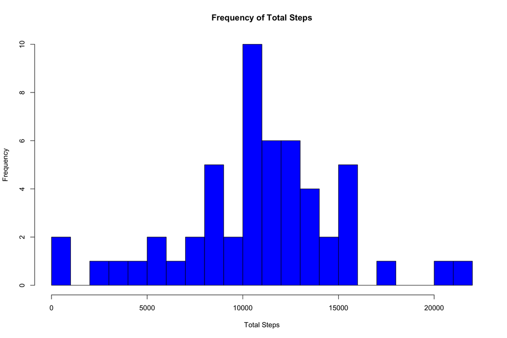

```r
hist(activity_data_sum$Total_Steps, col="blue", breaks=30,
     main="Frequency of Total Steps", xlab="Total Steps")
```

## What is the average daily activity pattern?

Calculating the average daily activity pattern involves manipulating the data set and cleaning some entries, particularly the interval column. To accomplish this:

```
   1. Pad the interval column where needed to maintain consistent 4-digit width. The interval corresponds to the hour
      [0000 - 2355] in the 24-hour military system.
   2. Create 'Date_Time' column and convert to POSIX using the function ymd_hm() from the lubridate library.
   3. Find the number of missing steps. This corresponds to NA entries in the data set.
   4. Group by interval, select the columns - step, date, interval - and calculate the average number of steps per
      interval. This will generate a table with all the average steps taken per interval time.
```

```r
activity_data_save <- activity_data
activity_data$interval <- str_pad(activity_data$interval, width=4, side="left", pad = "0")

activity_data <- (activity_data %>% mutate(Date_Time=ymd_hm(paste(date,interval), tz=Sys.timezone())))
num_of_missing_steps <- nrow(activity_data[is.na(activity_data$steps),])
```

The number of missing steps is 2304.

## Which 5-minute interval, on average across all the days in the dataset, contains the maximum number of steps?

Finally, create a new table, called activity, which contains the average number of steps taken per interval. This is accomplished by:

```r
activity <- (activity_data %>% group_by(interval)
                           %>% select(steps, date, interval)
                           %>% summarize(avgStepsPerInterval= mean(steps, na.rm=T)))
```

The interval with maximum average number of steps is 0835 with average number of steps at 206.

## Imputing missing values

To impute missing values, scan the data for “NA” steps, and replace the missing data with the calculated average steps per interval, as computed above.

```r
 for (r in c(1:nrow(activity_data)) ) {
  if (is.na(activity_data$steps[r]) ) {
      rth_interval <- activity_data$interval[r]
      activity_data$steps[r] <- activity[activity$interval==rth_interval,]$avgStepsPerInterval
  }
}
```

Compute the daily total steps and calculate the mean/median.

```r
imputed_activity_data_sum <- round(with(activity_data, tapply(steps, date, sum,    na.rm=F)))

imputed_meanSteps   <- mean(imputed_activity_data_sum)
imputed_medianSteps <- median(imputed_activity_data_sum)
```

```r
imputed_meanSteps
```

[1] 10766.16

```r
imputed_medianSteps
```

[1] 10766

Convert the table into a data.frame for the histogram plots.

```r
imputed_activity_data_sum <- as.data.frame(imputed_activity_data_sum)
imputed_activity_data_sum <- cbind(as.Date(rownames(imputed_activity_data_sum)), imputed_activity_data_sum)
rownames(imputed_activity_data_sum) <- seq(1,nrow(imputed_activity_data_sum))
names(imputed_activity_data_sum) <- c("Date", "Total_Steps")
```

Here is a table of the imputed data:

```r
head(imputed_activity_data_sum, n=20)
```

```
##          Date Total_Steps
## 1  2012-10-01       10766
## 2  2012-10-02         126
## 3  2012-10-03       11352
## 4  2012-10-04       12116
## 5  2012-10-05       13294
## 6  2012-10-06       15420
## 7  2012-10-07       11015
## 8  2012-10-08       10766
## 9  2012-10-09       12811
## 10 2012-10-10        9900
## 11 2012-10-11       10304
## 12 2012-10-12       17382
## 13 2012-10-13       12426
## 14 2012-10-14       15098
## 15 2012-10-15       10139
## 16 2012-10-16       15084
## 17 2012-10-17       13452
## 18 2012-10-18       10056
## 19 2012-10-19       11829
## 20 2012-10-20       10395
```

Here is the new histogram with the imputed data.

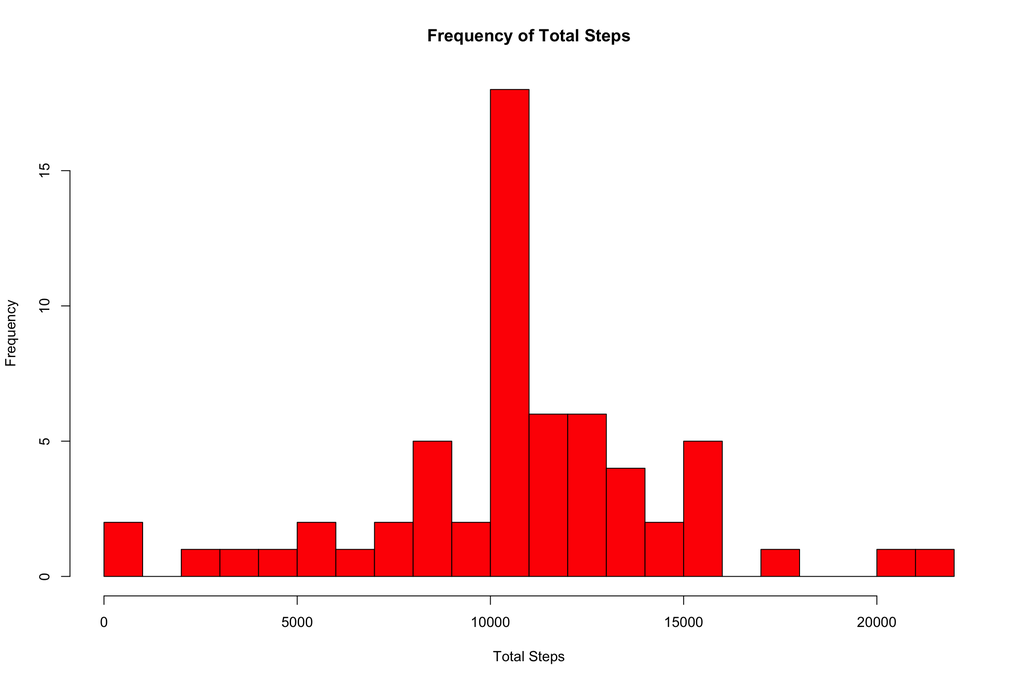

```r
hist(imputed_activity_data_sum$Total_Steps, col="red", breaks=30,
     main="Frequency of Total Steps", xlab="Total Steps")
```

Create a new column to indicate Weekday/Weekend. This will allow calculating the average steps per Interval grouped by weekday/weekend.

```r
activity_data <- (activity_data %>% mutate(Day=weekdays(Date_Time)))
activity_data <- (activity_data %>% mutate(Weekdays=ifelse( (Day %in% c("Saturday", "Sunday")), "WEEKEND", "WEEKDAY")))

imputed_activity <- (activity_data %>% group_by(Weekdays, interval)
                                   %>% select(steps, date, interval, Weekdays)
                                   %>% summarize(avgStepsPerInterval= mean(steps)))
```

## Are there differences in activity patterns between weekdays and weekends?

Plot the imputed_activity table and display the results based on the Weekday/Weekend.

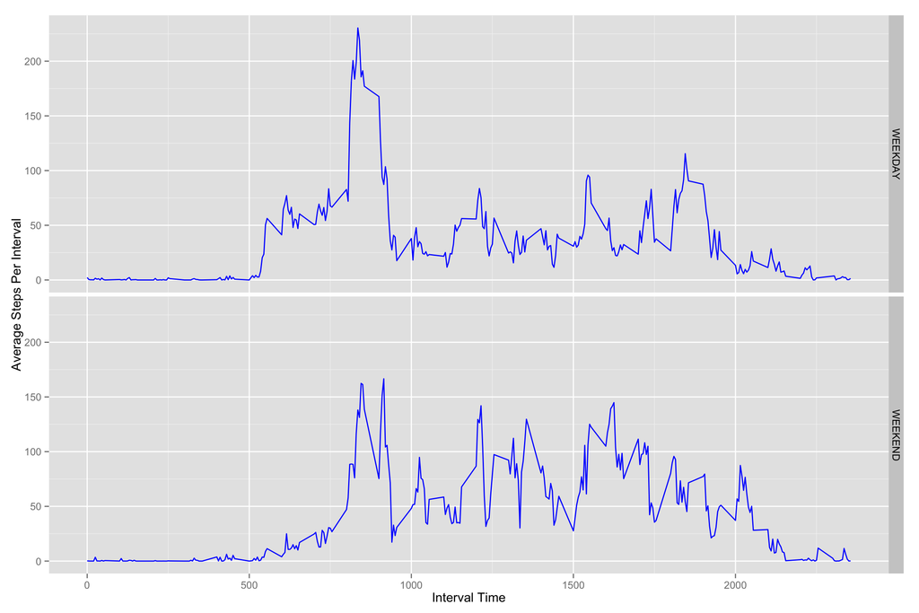

```r
p <- ggplot(imputed_activity, aes(x=as.numeric(interval), y=avgStepsPerInterval)) +
     facet_grid(Weekdays~.) + geom_line(colour="blue") +
     xlab("Interval Time")  + ylab("Average Steps Per Interval")
p
```

## Conclusion

There is a difference in activity levels between weekday and weekend. The **greatest spike** is during the weekday morning, possibly when the individuals are commuting to work or exercising. The weekend activity showed more consistent averages throughout the day. The greatest spike on the *weekends* was also in the morning, indicating possible routine exercise being performed. No activity was seen during night hours, where individual may be sleeping or sendentary.